# Indirect economisation

The role of economic calculative techniques in electricity system regulations

Henrik Karlstrøm, William Throndsen and Antti Silvast

2017-08-23

## Preprint licensing

*This is a preprint of an article, meaning it has not yet been subjected to peer review but may appear somewhat altered as a published article at some point in the future. This work is licensed under a [CC-BY Attribution 4.0 International](https://creativecommons.org/licenses/by/4.0/) license. You are free to share (copy and redistribute in any medium or format) and adapt (remix, transform, and build upon ) the material for any purpose, as long as you give [appropriate credit](https://wiki.creativecommons.org/wiki/License_Versions#Detailed_attribution_comparison_chart), provide a link to the license, and indicate if changes were made. You may do so in any reasonable manner, but not in any way that suggests the licensor endorses you or your use. Of course, it is only polite to let the authors know if you are using this for anything, so let us know if this is the case.*

# Abstract

Since the 1990s, most European countries have undergone some degree of liberalization of their electricity infrastructures. This has meant exposing parts of the energy sector, such as power generation, to competitive entry, while keeping its other parts, such as electricity grids, intact as regional monopolies operating alongside liberalised energy markets. Inspired by earlier studies on economisation and valuative regimes, this paper investigates the consequences of this transition, using the Norwegian case as an example. We argue that the transition does not constitute economisation in the traditional sense because vital parts of the grid sector remained publicly regulated monopolies. Instead, we find the transition included a shift in governing logic from one soundly rooted in engineering and controlled by elected politicians to one influenced chiefly by economics and controlled by complex calculative regimes in which elected officials are studiously hands-off. We argue this constitutes a form of indirect economization. This process of indirect economisation has had obvious implications for the degree of democratic control over vital societal infrastructure. Thus, we argue that processes of indirect economisation, sure to be found working elsewhere as well, should be studied alongside general economisation in order to grasp clearer their implication in modern, liberal societies.

## Correspondence

Henrik Karlstrøm, William Throndsen, Antti Silvast

University Library, Norwegian University of Science and Technology, NTNU, Email

Department of Interdisciplinary Studies of Culture, Norwegian University of Science and Technology, NTNU

School of Social and Political Science, University of Edinburgh

# Keywords

calculative techniques; economisation; energy infrastructure;

# Introduction

This articles seeks to shed light on the role of economic calculative techniques in the regulation of important societal functions in a modern market-based political economy. We study what kind of mathematical formulas and numbers underpin these techniques, and their changes in recent times. To these ends, we utilise recent concepts from the fields of social studies of markets and valuation studies. We exemplify them by the case of changing regulatory regimes for the income of electricity grid companies in Norway, comparing the current market-based system to the previous regime of total state control over the electricity sector from production to delivery via the grid.

Liberalised energy infrastructures have become the norm throughout Europe in recent decades. This has mostly come about through a transition from a centrally planned, state controlled energy sector to a division between regional distribution monopolies operating alongside competitive suppliers. We investigate this transition in the Norwegian context. Focusing on the grid sector we discuss the implications of transforming the ruling logic of the sector from one grounded in infrastructural and technological development to one of complex, bureaucratic calculative techniques in service of optimizing the status quo.

These questions are not just of academic interest. They form part of a political discussion about how to govern an increasingly complex society in an acceptably democratic way. As Rowland and Passoth point out in a review of recent literature on infrastructure and the state, studying «state *through* infrastructure and the state *in* infrastructure» (Rowland and Passoth 2015, emphasis in original) is a crucial part in understanding how decisions that affect broad swathes of society are structured. Of course, this also has political implications: «to be political in this era is to raise questions about how the state works» (Guldi 2012) [p. 3]. Studying the techniques by which governance happens is equally important to pointing out that governance is taking place in the first place.

Rowland, Nicholas J, and Jan-Hendrik Passoth. 2015. “Infrastructure and the state in science and technology studies.” Sage Publications.

Guldi, Jo. 2012. “Roads to Power.” *Britain Invents the Infrastructure State, Cambridge Mass./London*.

The interest in techniques or technologies of government has been a recurring topic of much thought on the organisation of modern society, perhaps really picking up steam with the lectures of Foucault on political government (see Collier (2009)) and later O’Malley (2012) and especially the work on critical infrastructure protection by Collier (2011) and Lakoff (2008). These thinkers highlight the importance of examining the interplay of technology, legislative bodies and regulatory institutions and documents when examining how governance works and comes to be.

Collier, Stephen J. 2009. “Topologies of Power.” *Theory, Culture & Society* 26 (6): 78–108.

O’malley, Pat. 2012. *Risk, uncertainty and government*. Routledge.

Collier, Stephen J. 2011. *Post-Soviet social: neoliberalism, social modernity, biopolitics*. Princeton University Press.

Collier, Stephen, and Andrew Lakoff. 2008. “The vulnerability of vital systems: How ‘critical infrastructure’became a security problem.” *The Politics of Securing the Homeland: Critical Infrastructure, Risk and Securitisation*. Routledge, 40–62.

Here we complement these general social science considerations by focusing on the governance of economic matters specifically. Çaliskan and Callon (2009; 2010) have called for studies of what they call *economisation*, looking at how ever more aspects of society become the object of economic logics and fall under the purview of the field of economics. They mostly focus on how new areas of life become governed by market mechanisms, so-called *marketisation*, but they also discuss how the logic of competition and the tools, concepts and materials of economics render a phenomenon that used to be seen as outside the grasp of the market as ‘economic’. Following this, (Breslau 2013) has used economisation theory to analyse the construction of what he calls market-like entities, parts of the electricity infrastructure of the US that is now being subjected to pseudo-competition and financialisation in order to attain the appearance of a competitive market. (Karlstrøm 2012) and (Silvast 2017b) have shown how similar processes have been going on in Norway and Finland respectively.

Çalışkan, Koray, and Michel Callon. 2009. “Economization, part 1: shifting attention from the economy towards processes of economization.” *Economy and Society* 38 (3). Routledge: 369–98.

Çalışkan, Koray, and Michel Callon. 2010. “Economization, part 2: a research programme for the study of markets.” *Economy and Society* 39 (1). Routledge: 1–32.

Breslau, Daniel. 2013. “Designing a market-like entity: Economics in the politics of market formation.” *Social Studies of Science* 43 (6): 829–51.

Karlstrøm, Henrik. 2012. “Empowering markets?: The construction and maintenance of a deregulated market for electricity in Norway.” Norwegian University of Science & Technology.

Silvast, Antti. 2017b. *Making Electricity Resilient: Risk and Security in a Liberalized Infrastructure*. Taylor & Francis.

However, there are sectors of society that are not being turned into such market-like entities. With previously integrated societal functions such as infrastructure maintenance becoming separated into market-exposed companies and ‘natural monopolies’, the latter are finding themselves governed by a new set of financial regulations. This is happening even when - according to the original intention - these parts of infrastructures were not supposed to be subjected to market competition and hence efficiency gains. This is certainly a form of economisation, although not in the direct sense of Çaliskan and Callon. Rather, it might be called indirect economisation. Our claim is that the indirect way in which such economisation processes happens has consequences for our understanding of the room for democratic control over vital societal infrastructure.

In the upcoming sections we further elaborate the concept of economisation and valuation theory to understand the methods by which economisation has been carried out. We then provide the background of the Norwegian electricity grid regulation regime and an overview over how the governing logic of this system has changed considerably after the introduction of the market liberalisation and the separation of grid operation into natural monopolies. This is intended as a concrete example of how indirect economisation poses some interesting quandaries for the governance of infrastructure and other important societal sectors in modern market society. We argue that this transition to a system of indirect economisation has an impact on the possibilities for transparency in a process that ultimately decides a large part of the costs to end users of having a functional infrastructure that supports almost all aspects of everyday life.

# Economisation

A recent meeting of science and technology studies and economic sociology has resulted in a turn away from structural explanations of the effect of economic phenomena in the social field and towards examining concrete methods of defining, delineating and regulating what Çaliskan & Callon have dubbed *the economic*: «Rather than asking what *the economy* (noun) is, there has been a shift towards defining observable criteria which enables one to say that an activity, behaviour or institution is *economic* (adjective)» (Çalışkan and Callon 2009)[p.371]. This allows one to start tracing the way a specific set of logics, tools and techniques taken from the field of economics is moved into new fields and brought to bear on issues that were previously considered to operate under logics of their own.

Çalışkan, Koray, and Michel Callon. 2009. “Economization, part 1: shifting attention from the economy towards processes of economization.” *Economy and Society* 38 (3). Routledge: 369–98.

One example of this movement is the change in how radio frequencies have been awarded to potential stations in the US since the 1990s. Instead of (somewhat paternalistically) considering ‘the public good’, regulators now set up auctions and offer frequencies to the highest bidder, using auction theory from economics (Dunbar-Hester 2014). This marked a shift in governing logics, but also of course a shift in power to one type of market actor (commercial radio stations) away from another (non-profit or communal radio stations). Economisation theory claims that tracing the movement of such conceptual and theoretical tools as well as the concrete technologies by which concepts manifest themselves is a necessary condition for understanding the outcomes of these processes, and ultimately one central aspect of the development of modern market-based politics and society.

Dunbar-Hester, Christina. 2014. *Low power to the people: Pirates, protest, and politics in FM radio activism*. MIT Press.

To date, by far the most common utilisation of economisation theory and its sibling concept of performativity has been in the study of the financial sector. It has been used to show how specific economic framings of the function of the stock market and other financial institutions have led to a historic decoupling of the financial sector from other parts of society. This has potentially laid the ground for an increasing leveraging of financial institutions through acceleration of the circulation of money to the point where humans are barely capable of understanding the entanglements (MacKenzie, Muniesa, and Siu 2007; MacKenzie 2008). While finance is a topic that is particularly suited for analysing the power of economic tools due to the training financial agents get in this very economic theory, more recent work on the increasing importance of economic logics also engage with other aspects of economisation, such as the introduction of economic logics in the life sciences (Dussauge, Helgesson, and Lee 2015) and the embedding of economic reasoning in non-economic relational work (Zelizer 2012). The social studies of markets approach has also grown in prominence in the study of the energy infrastructure and energy transitions, though this research topic is still emergent (see (Silvast 2017a) for an overview).

MacKenzie, Donald, Fabian Muniesa, and Lucia Siu. 2007. *Do economists make markets?: on the performativity of economics*. Princeton: Princeton University Press.

MacKenzie, Donald. 2008. *An engine, not a camera: How financial models shape markets*. Mit Press.

Dussauge, Isabelle, Claes-Fredrik Helgesson, and Francis Lee. 2015. *Value Practices in the Life Sciences and Medicine*. Oxford University Press.

Zelizer, Viviana A. 2012. “How I became a relational economic sociologist and what does that mean?” *Politics & Society* 40 (2). Sage Publications: 145–74.

Silvast, Antti. 2017a. “Energy, economics, and performativity: Reviewing theoretical advances in social studies of markets and energy.” *Energy Research & Social Science* 34. Elsevier: 4–12.

Because of its focus on the material dimensions of such processes, economisation theory is particularly suited for shedding light on the increasingly depoliticised processes by which economic logics inform and influence public governance. Following economic materiality can account for changes in the economy, with the understanding that new tools, methods and techniques can lead to new economic phenomena. This is the reasoning behind the interest in so-called ‘market devices’, algorithms, trading schemes, price formulas and similar techniques that are the battlefield of complex technical deliberations that ultimately guide much of modern life (Callon, Millo, and Muniesa 2007). The main interesting feature of these parts of the modern informational infrastructures, as MacKenzie and Millo (2003) call them, are that as they have specific material effects, they are technologies which can be followed and analysed with some precision.

Callon, Michel, Yuval Millo, and Fabian Muniesa. 2007. “Market Devices.”

MacKenzie, Donald, and Yuval Millo. 2003. “Constructing a market, performing theory: The historical sociology of a financial derivatives exchange.” *American Journal of Sociology* 109 (1). The University of Chicago Press: 107–45.

Still, economisation theory has only barely started to scratch the surface of a rapidly expanding and polymorphous field. As Çaliskan and Callon point out, the marketisation processes they study represent merely one of many points of attack along these lines. This article tries to go beyond previous discussions of economisation and into areas which exhibit some of the same traits as ‘straightforwardly’ economised sectors of society, but where these traits emerge almost as a by-product of changes that happen in related, neighbouring sectors of the economy. Such processes of what might be called indirect economization would denote areas of society that are not exactly privatized or turned into pseudo-markets but are still affected by such processes.

One case with the potential for revealing effects of indirect economization is the regulation of the income of the Norwegian electricity grid companies, which due to the deregulation of the production side of the electricity system has had its status changed from an integrated part of electricity utilities to being separated into stand-alone companies whose only task is to maintain the electricity grid. Since the grid is now considered a ‘natural monopoly’ with a series of regionally based, non-competitive companies, their potential to misuse the monopoly status to extort unduly high profits is tightly controlled by a complex set of regulations, bureaucratic techniques and algorithms that are the subject of annual legal conflicts between the state and the grid companies.

These legal conflicts are under the post-liberalized system a new phenomenon governing the grid sector. Their outcomes are only visible to a very small set of professionals involved in the negotiations around the income regulation of grid companies, but they potentially affect every single electricity user in the country. By tracing the intricacies of the regulations and how it has evolved under the post-liberalized era, we see how the different actors mobilize economic concepts and calculative techniques to win the argument for their side. It is possible to get a grasp of how economisation of one sector - the production side of electricity - can have deep and lasting indirect consequences for a different one. However, to do this, an understanding of valuative regimes is necessary.

# The role of calculations

Markets rely on the successful use of calculative regimes to provide information about the monetary value of goods and services that might carry with them a large degree of uncertainty (Karpik 2010). These calculative regimes are, of course, not neutral. They rely on specific assumptions about what should be part of the calculation and what shouldn’t, and even more on what is considered to be valuable: «We can never simply *calculate* because we must do so with units and instruments of measurement that are deeply structured by accounts of what can be of value» (Stark 1996)[p. 53].

Karpik, Lucien. 2010. “Valuing the Unique: The Economics of Singularities.” *Economics Books*. Princeton University Press.

Stark, David. 1996. “Recombinant property in East European capitalism.” *American Journal of Sociology* 101 (4). University of Chicago Press: 993–1027.

Calculations can powerfully shape the conditions under which choices are made and determined. This may be linked with what many have identified as the increasingly technocratic nature of modern political decision making. As ever more decisions by policy makers are made with reference to predictions of future developments or the application of carefully framed statistics, a new set of ‘de-politicised’ policy decisions that nevertheless can have large actual implications for citizens arise (Lamont 2012). In situations where the traditional logic of politics no longer carries with it the same weight, calculations themselves often become the site of controversy - rather than debate ideology, one argues over technicalities. Controversies, while reflecting at times deep-seated differences in ideological outlook, often take the form of disagreements about the technical aspects of regulatory regimes. Calculations become proxies for differences in politics. At the same time, calculations and technicalities are often hard to understand for those affected by these technical decisions. Even if technical solutions provide procedural stability, movement from politics to technicalities carries with it a political aspect all of its own.

Lamont, Michèle. 2012. “Toward a comparative sociology of valuation and evaluation.” *Annual Review of Sociology* 38.

Much of the valuation literature has focused on the discursive frames that allow one to perform calculations on previously incommensurable entities (Lamont 2012). These frames can be specific categorisations (classification, standardisation etc.) or legitimisation efforts of contestation and negotiation (Timmermans and Epstein 2010). However, taking the economisation theory discussed above into consideration it might be equally interesting to study the concrete socio-technical infrastructures which underlie calculations and make them possible. A focus on these infrastructures can demonstrate not only the sites of controversy, to borrow a term from Nelkin (1992), but provide specific, empirical examples of where these controversies play out and review their consequences. In the following, we will review and compare the governing logics of the pre- and post-liberalised grid regimes. We wish to show that the way a set of specific calculations are framed and carried out is the cornerstone of a change in regulatory policies that can have far-reaching effects.

Lamont, Michèle. 2012. “Toward a comparative sociology of valuation and evaluation.” *Annual Review of Sociology* 38.

Timmermans, Stefan, and Steven Epstein. 2010. “A world of standards but not a standard world: toward a sociology of standards and standardization.” *Annual Review of Sociology* 36. Annual Reviews: 69–89.

Nelkin, Dorothy. 1992. “Controversy: politics of technical decisions.”

# The Norwegian electricity system

The story of the Norwegian electricity system is both typical and somewhat special. Blessed with an abundance of waterfalls and a commitment to providing citizens (and, lest we forget, businesses) with cheap and secure sources of electricity, the developers of the Norwegian electricity system spent the first sixty years of the 20th century expanding the production and distribution capabilities of electricity utilities.

From the start, the electricity system was conceived as a total service provider to the Norwegian public - it should provide sufficient amounts of electricity at reasonable prices to end users and maintain an electrical grid that would ensure security of delivery through adverse situations such as dry autumns, cold winters or sudden surges of demand (Thue 1996). Under the prevailing engineering logic of the post-war period, it was considered most rational that production and distribution be kept within the same unit. Maximum stability both for customers and utilities would be achieved through the construction of regional monopolies for supplying power, where profits from the sale of electricity would subsidise the maintenance of the grid.

Thue, Lars. 1996. “Strøm og styring: norsk kraftliberalisme i historisk perspektiv.” Ad notam Gyldendal.

One feature of this commitment to guaranteed supply of electricity was the need, under an engineering dominated logic, to ensure that the system could run even during demand peaks (Throndsen and Ryghaug 2015). As a consequence the Norwegian electricity system was somewhat over-dimensioned. Construction of new plants was started before demand could completely catch up with supply, often with an eye to which strategic developments could be had from it, for example through stimulating growth in certain parts of the country by opening hydro plants where one wanted to attract industry.

Throndsen, William, and Marianne Ryghaug. 2015. “Material participation and the smart grid: exploring different modes of articulation.” *Energy Research & Social Science* 9. Elsevier: 157–65.

From the point of view of supply and demand, this was an enormous waste of societal resources. The system relied entirely on a form of centralized planning that in the 1980s was beginning to be viewed with a certain scepticism both from social scientists (economists and political scientists) and political agents in general. Rather, there was a move towards what was seen as a more organic, self-organising principle of supply and demand with regards to business and the dimensioning of infrastructures. It would no longer be the role of the central state to dictate where and under what circumstances businesses should locate.

Before the liberalisation of the Norwegian electricity market in 1990, there was no general public market for electricity in Norway. Rather, there was a limited and internal auction-based electricity trading scheme within Norway and between certain actors and their international counterparts [Kaijser and Hedin (1995); Silvast (2017b)), and the sector was subject to strict price controls. Prices were set by Parliament on a yearly basis, based on engineers’ predictions of the long-term marginal cost of production (LTMCP) for electricity, which took into account the cost of building new plants with a certain depreciation factor as well as predictions of future demand levels.

Kaijser, Arne, and Marika Hedin. 1995. “Nordic Energy Systems.” *Historical Perspectives on Current Issues*.

Silvast, Antti. 2017b. *Making Electricity Resilient: Risk and Security in a Liberalized Infrastructure*. Taylor & Francis.

The LTMCP is an interesting case of one type of economic calculative technique that was present in the Norwegian electricity infrastructure from the very start. It relied on a specific set of assumptions that were seldom challenged, and which shaped both the way Norwegians were allowed to use electricity and the very landscape of the country itself. The LTMCP represents a typical engineering approach to infrastructure dimensioning. By assuming that the demand for electricity was linearly scalable and projecting historical trends into the future, it was calculated according to a formula similar to the following, which is still used to a certain degree in making projections of the future price of electricity.

A typical LTMCP equation:
$$LTMCPy = \sum_{t=T_i}^{T_f}a_t\frac{\Delta C_p(t)\times (1+p)^{-(t-YR)}}{\Delta P(t)\times (1+p)^{-(t-YR)}}$$

In this formula, the yearly long-term marginal cost of production of electricity is seen as a function of the yearly cost of constructing the new plants that would be needed because of the linear growth in demand as averaged over a period of some t years (usually 30) combined with the actual marginal cost of producing an extra kWh of electricity in existing plants. Because the marginal cost of hydroelectricity after initial investments are made is very low, old power plants become very profitable after some decades, and the added income from some of the older utilities in the south of Norway was used, together with handsome state guarantees, to subsidise newer less profitable ones. Through the linking of profits from old plants and subsidies for constructing new plants, the system worked to perpetuate itself, with ever more power plants being constructed as a result, sometimes at great cost both to taxpayers and to local environments.

As mentioned, this way of operating was not seen very favourably by economists. Not only did it entail the use of regional monopolies for the production of electricity, but there was also governmental price control, meaning utilities had little chance or incentive to make changes to achieve efficiency gains. In addition, the use of cross-subsidies internally in the utilities and tax-funded state guarantees in cases of loss of income for utilities meant that it was very opaque what the production of electricity was really costing the Norwegian public.

Through a concerted effort over decades from economists, entailing the production of more than sixty research reports and hundreds of public debate articles from economists working at the Norwegian School of Economics, combined with the general shift towards more market-oriented forms of governance through the 1980s that saw the election of the first non-Labour government in a long time in 1989, a shift from an engineering logic to an economic logic happened. In 1990, a new Energy Act was passed, splitting electricity production and distribution into two sectors with different governance logics.

In the current setup the Norwegian electricity system after production and sale of electricity is separated from distribution and grid maintenance. In contrast to the politically defined electricity price of yore, prices are now set in the competitive market for production utilities. For end-use, the role of the consumer is reacting to price information. The Norwegian Competition Authorities provide consumers with a continuously updated web portal where they can compare prices and different pricing schemes. Norway has also been very active in reducing barriers to utility changing. Without a doubt, Norwegian households have been encouraged to see themselves as actors in a market for electricity that should engage in price arbitrage, i.e. the possibility to switch between competing utilities in order to keep prices down and the pressure for efficiency on the side of companies up (Karlstrøm 2012). There is also a role for electricity trading and price arbitrage between utilities, and some companies have sprung up that just broker delivery contracts between utilities.

Similar portals exist in other countries, such as the UK (http://www.ukpower.co.uk/) and Finland (http://www.sahkonhinta.fi)/

Karlstrøm, Henrik. 2012. “Empowering markets?: The construction and maintenance of a deregulated market for electricity in Norway.” Norwegian University of Science & Technology.

# Gridlock

This shows how the production side of electricity was identified as a prime target for a conscious economisation effort, moving from an engineering logic to using the tools of economics to deliver a new politics of electricity in Norway. What about the other side of the system, the grid companies that could not be subjected to competition because it makes no sense to impose competition on physical infrastructure? Like other fixed infrastructures such as roads or railroads, the governance of the electricity grid is still considered a ‘natural monopoly’ in economic terms. This is due to the nature of these systems, where it makes very little sense to try and construct competing systems alongside the existing ones. Rather, ways to simulate competition are sought. This often takes the form of public regulation of the maximum income of the grid companies, encouraging them to focus on improving efficiency rather than increasing prices in order to receive increased revenue.

In order to avoid the possible misuse of their monopoly status, Norwegian grid companies see their income strictly regulated by the Norwegian Water and Energy Directorate (NVE). NVE subjects the grid companies to yearly price controls based on reports of the size their customer base, projections of their costs in the coming year and calculations of a large set of other factors such as land rent, interest rates, equipment investment depreciation and the like. These price controls rely on a host of calculative techniques to be effective, which are constantly being challenged by the companies subjected to them. These techniques range from projections of economic development and simulated future demand to retroactive adjustments of budgets to fit updated information about costs and income. This is obviously constitutes a case in which we have calculative devices that MacKenzie (2008) would refer to as having *effective* rather than *generic* performativity. As we shall see in the following, their introduction marks a significant difference compared to the situation in which they were absent.

MacKenzie, Donald. 2008. *An engine, not a camera: How financial models shape markets*. Mit Press.

The figure below gives a partial picture of how one such calculation of the income roof for a grid company is produced. It was used in determining the income roof of grid companies in 2007, and is taken from one of the procedural documents used by NVE to determine the allowed income roof for the period 2006-2008. This document details not only the process NVE follows to establish the yearly allowed income for the grid companies, but also the procedure whereby the companies have an opportunity to contest the findings of NVE on the basis of wrongful representation of their own or NVE’s data. Of course, in the final instance NVE is still regulator, and acts as judge in determining the merit of a complaint or counter-calculation, but the document lays out the reasoning behind each calculation and appeals decision.

«Complaints regarding decisions about income roof for 2007Â (NVE 200802911-12)

Figure 1: An example of some of the calculations for grid company income regulation

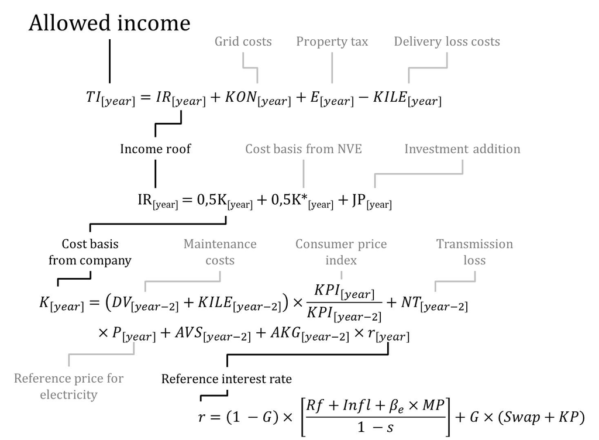

In this formula, we see a single, seemingly simple formula for the calculation of the current year’s allowed income (*TI*<sub>[year]</sub>) at the top, containing only four terms. However, these terms are themselves nested formulas containing more terms that can be traced in other policy documents. Each of the terms of the formula needs to be specified according to rules found in other regulatory documents scattered between different regulatory bodies with very different scopes of action, such as the Ministry of Energy, NVE, Statistics Norway and the Central Bank.

The formula for calculating allowed income for grid companies:  
*T**I*<sub>2007</sub> = *I**R*<sub>2007</sub> + *K**O**N*<sub>2007</sub> + *E*<sub>2007</sub> - *K**I**L**E*<sub>2007</sub>

To take only the general formula itself, the state provides companies with a calculation of yearly grid costs (*KON*<sub>[year]</sub>), municipalities impose property taxes (*E*<sub>[year]</sub>) and there is a separate calculation for what is termed costs of delivery loss (*KILE*<sub>[year]</sub>) that are incurred when the grid company fails to deliver electricity to institutional customers (such as factories or hospitals) that rely on secure and constant delivery of electricity. The municipal property taxes are the result of yearly political negotiations and belong to a process separate from the grid regulation. The delivery loss costs result from legal processes where NVE afford institutional customers compensation according to the strength of their claims of damages incurred from loss of delivery from the grid companies. These legal processes are solved according to separate calculative processes detailed in a different set of regulatory documents.

The formula for calculating income roof for a given year:  
*I**R*<sub>2007</sub> = 0, 5*K*<sub>2007</sub> + 0, 5**K*<sub>2007</sub> + *J**P*<sub>2007</sub>  
To demonstrate the bureaucratic complexity of these calculative techniques, we can further unpack one of the nested terms of the original *TI*<sub>[year]</sub> calculation, the income roof (*IR*<sub>[year]</sub>). While acting as an input term in *TI*<sub>[year]</sub>, it is itself a formula consisting of three terms. The last term, the *investment addition* (*JP*<sub>[year]</sub>), is an additional term that allows for the company investments. Similarly, the grid company contributes their account of cost basis for a given year, and NVE provide what they call a cost norm for what they expect a company of a certain size and scope to have in costs, and these two terms each make up half of the final cost basis (hence the cost basis *K* is set to 0,5 each for the company and NVE).

The terms involved in calculating a company’s cost basis for a given year:
$$K_{2007} = (DV_{2005}+KILE_{2005})\times \frac{KPI_{2007}}{KPI_{2005}}+NT_{2005}\\
\times P_{2007} + AVS_{2005} + AKG_{2005}\times r_{2007}$$
While it is not possible to discern how NVE calculate their half of K from the above mentioned document, the company is required to provide a break-down of the number, given as a set of terms in *K*<sub>[year]</sub>. These are the costs of running and maintaining the electricity grid (*DV*<sub>[year-2]</sub>)in the formula), the general rise in costs given by the consumer price index (*KPI*<sub>[year]</sub>, which is provided yearly on the basis of calculations by Statistics Norway), a reference price of buying electricity through the electricity exchange NordPool (*P*<sub>[year]</sub>, set on the basis of the weighted average monthly consumption in the various grid regions of Norway) and some more terms for write-downs of the value of invested grid capital (*AVS*<sub>[year-2]</sub> and *AKG*<sub>[year-2]</sub>).

Calculating the general interest rate for a given year:
$$r_{2007} = (1-G) \times \frac {R_f + Infl + \beta_e \times MP}{1-s}\\
+ G \times (Swap + KP)$$

The last term of *K*<sub>[year]</sub> is the general reference interest rate *r*<sub>[year]</sub>. This number is provided by the Bank of Norway each year as an average of the interest rates it provides throughout the year. The determination of the interest rate relies on a host of terms concerning financial and economic issues ranging from the state of the housing market, the general employment level, the consumer price index (which also featured in the formula of *K* that *r*<sub>[year]</sub> is a part of in the case of the costs that grid companies have during a year) and other pertinent factors, and is a part of the normal operation of the political-economic body that is the central bank. Each of these terms is itself the result of calculative negotiations originating elsewhere in the socio-technical regime of ‘the economy’. And here, on the fourth nested iteration of one regulatory calculation among many, it is time to stop so as not to drown in calculative terms.

# Calculative democracy

As we can see, the construction of a single number that ultimately determines how much the grid company is allowed to charge its customers in a given year rests on a host of other calculations. These again are subject to the same calculative and re-calculative techniques that lend weight to their legitimacy, so that trying to follow all of them leads to a merry dance of justificatory calculations and numbers that may seem abstract but which have real consequences. Untangling these calculations and tracing their lineage through other calculations reveal something about the nature of technologies of governance, but it still remains a rather opaque process. Even armed with the level-headed and thorough explanation of all the terms of the various formulas that prefaces all the documents consulted in this case, it is hard to evaluate the value of the claims made by the calculations. For example, knowing that a reference rate of discounts for investments (*JP*<sub>[year]</sub>) exists does not provide much of an explanation of who came up with that particular formula, which deliberations went into its inclusion (and the exclusion of other terms) or even what that number is - this is proprietary information, only shared by NVE and the company in question. A look at these formulas also reveals the importance of paper trails in modern bureaucracies. While the specific formulas that govern grid company income were found in a single policy document, their genesis and the calculative rationale behind them cannot be found in any one place - in fact, to arrive at the very limited overview of Figure 1 provided above a total of eight different documents must be consulted (see Appendix), and this is leaving out the terms that come from the financial sector or the careful calculations of the central statistical bureau of Norway. Rather, the varying rules for determining the input factors in the formulas are detailed in a bewildering array of regulatory documents, not all of which are made public for more than the short period of time they are up for negotiation between the grid companies and the state. It is also not always clear where one can go to identify the terms used in the various calculations, as these regulatory documents only sometimes carry references to other such documents. On the whole, the process strongly relies on the competencies of a few insiders with the tacit knowledge of where and under what circumstances such calculations are produced. All in all, it is questionable whether more than a few people in each company (or their hired consultants) as well as a small group in NVE ever take part in these negotiations or would know how to evaluate the claims and positions present. Yet the outcomes affect us all.

Another important aspect of these calculative techniques is their role as foci of contests of power between actors in the electricity market and the state. Every one of these calculations is the site of potential controversy. For example, by the time of the documents detailed above, it had been decided that the value for the cost norm of grid companies that was provided by NVE would be changed from 0.5 *K** to 0.6 *K** (and consequently, that the grid companies’ share of the cost basis would go down to 0.4 *K*) in order to reduce the impact of widely differing cost basis from the companies. This led to complaints from grid companies that the state, an external actor with limited insight into the internal economy of the companies, had a too large impact on the income of grid companies. These complaints were not borne out, as the NVE ruled that the state had the right to set the terms of income for the grid companies.

The correct compensation utilities have to pay customers in cases of lack of delivery, the *KILE* number, is another contentious calculation where large-scale buyers of electricity were also drawn in as afflicted parties in the legal push and pull between utilities and regulators. In fact, these calculations form the basis for sustained legal battles between grid companies which seek to maximise their annual income and the regulators that try to limit the abuse of monopoly power.

This is not to say that there is an entirely antagonistic relationship between the state and the grid companies. It is clear that in many ways the current regulatory system is the result of a longstanding negotiation and back-and-forth between regulator and regulated over the most suitable terms of engagement. If the positions were ever to move to far away from each other, the system would most likely experience a strain it has not so far done, as can be witnessed by the fact that most negotiations are done rather amicably. The point is rather that these factors - the nesting of calculations, the regulatory thicket, the contestedness of calculative techniques and valuative processes - all have an effect on who has a say in a vital infrastructure. As such, it has a bearing on how a vital matter of concern functions in the setting of a market-based democracy, and in the even wider sense, should inform our understanding of the possibilities for democratic control of highly complex and interconnected systems and infrastructures.

The liberalization of the Norwegian electricity market is often termed a deregulation, but given the immense amount of regulation connected to the control of the grid companies’ income this seems to be a misnomer. Rather, we might speak of a re-regulation rather than de-regulation. However, while reintroducing regulation is often hailed as a way of reinstating public control over what are deemed crucial socio-technical constructions for society, the example of the kinds of documents that form the regulatory core of this system would seem to imply that it would mostly be a question of handing decision-making control over to a new group of sequestered experts. After all, no-one can actually follow these controversies - both due to the actual negotiations largely going on behind closed doors and due to the sheer opaqueness of the calculative techniques and their documentation. There are few avenues of public engagement. These sites of battle are far away from participatory democracy, even if they constitute the core of what Lamont calls ‘burning topics’ in democracy (Lamont 2012).

Lamont, Michèle. 2012. “Toward a comparative sociology of valuation and evaluation.” *Annual Review of Sociology* 38.

The complexity of today’s arrangement calls to mind the black-boxing of technologies so well-known from science and technology studies, where the assumptions that underlie socio-technical solutions are removed from the public eye and placed in the black box. In this sense, it is somewhat ironic that every part of the income calculation process for grid companies in Norway is in principle in the open, with all documents obtainable from a public source (if only for a limited time frame, as with the document used as an example in this article), and yet the reasoning that is embedded in these documents is still so elusive. As such, it might make more sense to talk of a *photochromatic* box rather than a black one - it is seemingly transparent until light is shined directly on it, when it turns out to be opaque after all.

# Conclusion

In this article, we have tried to discuss the importance of paying close attention to the ways in which the on-going process of bringing economic reasoning to bear on what is essentially political processes can make a tiny contribution towards a deeper understanding of how modern society is governed. Economisation is about a specific framing/formatting of something as economic, but framing something is as much as about what is left outside the frame as what is placed in it. In the case of the Norwegian electricity market, when the production side was economised, or rather re-regulated as argued above, the distribution side had to be reconfigured to respond to the economization. In this sense, this can be seen as a by-product of the main economization process, an indirect economization.

The above discussion points to the obvious political nature of these supposedly depoliticised issues. Even if attempts have been made to cleanse the running of the electricity system of non-economic concerns, the negotiated nature of calculations show the clear implications increasing technocratisation has for the possibilities to manage large and complex technical systems in a democratic fashion. Indeed, we could say that economisation itself in this case has led to an increased technocratisation. Only a handful of experts will ever have access to the main guidelines that ultimately decide how much of citizens’ disposable income will have to go to paying for access to electricity, never mind actually understanding how these guidelines are made and what the consequences of minor changes to them are.

Of course, it could be convincingly argued that the previous situation - engineers making their long-term marginal cost of production calculations and delivering them to politicians who were not necessarily able to judge the quality of them - did not exactly invite much democratic deliberation either. In fact, there has never been a situation where a central infrastructure like the electricity system has not been dominated by a Weberian rational-legal authority. However, this is still not to say that rule by engineers or economists is equal in nature. Regardless of how opaque the previous situation was, there was at least the possibility of a political engagement due to the rounds the cost of our energy infrastructure had to make in an arena of democratic representation. Members of Parliament are perhaps not equipped to have the final say in what the ‘correct’ price of electricity should be, but it remains a fact that it used to make an appearance in a court of opinion every year, reminding us that the organisation of our infrastructure is a political as well as a technical question.

We would argue that the case of the economic performativity of processes of economisation of infrastructure, direct or indirect, is an interesting avenue for further exploration in order to seek answers to questions of democratically legitimate decision making or the reversibility of political decisions. A valuative investigation into the change process we have described in this paper would be instructive in this regard, as would any attention given to sites of indirect economisation as potentially more openly contestable sites of controversy.

## Acknowledgments

We wish to thank Knut H. Sørensen for giving the initial impetus to study this regulatory spaghetti.

The preprint was produced using the Tufte package for the R Markdown language.

## Appendix

List of regulatory documents detailing the calculation of grid company income regulation. Other relevant sources are posts from the electronic reporting tool eRapp, and draft versions of the calculations of cost norms that were the focus of debate in 2006.

| Type | Title |
| --- | --- |
| NVE Document 12/90 no. 959 | Regulation of the production, transformation, transmission, sale, distribution and use of energy etc. |
| NVE Document 3/99 no. 302 | Regulation of economic and technical reporting, income and tariffs of grid companies |
| NVE Report 4/2004 | Principles for regulating grid entities’ income |
| NVE Document 9/2005 | The economic regulation of the electricity grid |
| NVE Document 19/2005 | Changes in regulation 1999 no. 302 on economic and technical reporting |
| NVE Document 3/2006 | The economic regulation of the electricity grid. Proposition regarding changes to KILE, reference interest rate, investments adjustments etc. |
| NVE Document 11/2006 | The economic regulation of the electricity grid. Summary of the 2006 hearing and changes to the regulation of economic and technical reporting |
| NVE Note 08.12.2006 | On the designation of cost norm for 2007 |